# Case Study - How Does a Bike-Share Navigate Speedy Success?

#### Part of the Google Analystics Case Study Project.

# First Phase: Identify the business task.

In this case study, Cyclistic is a fictional company that offers a bike-share program that features more than 5,800 bicycles and 600 docking stations across Chicago. The director, Lily Moreno, has a goal to convert casual riders into annual members in order generate more revenue for the company. In order to achieve this, I am requested to analyze how annual members and casual riders use Cyclistic bikes differently. I am provided with a dataset that spans for 1 year to analyze and identify trends and generate insights. Casuals are identified as those who opted for single-ride passes or full-day passes, whereas members are identified as those who opted for an annual subscription.

### In order to achieve my goal, I have narrowed down the questions to the following:

- What is the total number of trips for members and casuals, and what proportion of total trips do they represent?
- What are the average ride lengths for members and casuals respectively?
- What are the most common starting and ending stations for each?
- Are there particular days of the week on which most rides take place?
- Is there a preference for the rideable type for members and casuals?

# Prepare Phase

### The data has these following fields (or columns):

- ride_id: Unique id for each ride
- rideable_type: type of bicycle used
- started_at: the date and time that the bicycle was checked out
- ended_at: the date and time that the bicycle was checked in
- start_station_name: the name of the station at the start of the trip
- start_station_id: a unique identifier for the start station
- end_station_name: the name of the station at the end of the trip
- end_station_id: a unique identifier for the end station
- start_lat: the latitude of the start station
- start_lng: the longitude of the start station
- end_lat: the latitude of the end station
- end_lng: the longitude of the end station
- member_casual: field indicating whether the bicycle was taken about by a member or a casual

As this is internal data, it is safe to assume that these data are unbiased and credible. Now, let's proceed to the process phase.

# Process Phase

### Tools to be used: Python.

For the entirety of this analysis, Python shall be used as the dataset has more than 3 million rows and would be unsuitable to be used on a spreadsheet software.

## Data Cleaning Process

```python
# Importing the neccessary packages
import os
# missingno is a useful package for visualizing missing values
import missingno as msno
import pandas as pd
import matplotlib.pyplot as plt
import seaborn as sns
import numpy as np
import datetime
%matplotlib inline
```

```python
#Mixed datatypes on start_station_id and end_station_id. Quick solution is to just convert it into a string.
os.chdir("Cyclistic_CSV_Datasets")
tripDf = pd.read_csv('First_Tidy_trip_data.csv', dtype = {'start_station_id': str, 'end_station_id': str})
```

```python
tripDf.head()
```

|  | ride_id | rideable_type | started_at | ended_at | start_station_name | start_station_id | end_station_name | end_station_id | start_lat | start_lng | end_lat | end_lng | member_casual |
| --- | --- | --- | --- | --- | --- | --- | --- | --- | --- | --- | --- | --- | --- |
| 0 | A847FADBBC638E45 | docked_bike | 2020-04-26 17:45:14 | 2020-04-26 18:12:03 | Eckhart Park | 86 | Lincoln Ave & Diversey Pkwy | 152.0 | 41.8964 | -87.6610 | 41.9322 | -87.6586 | member |
| 1 | 5405B80E996FF60D | docked_bike | 2020-04-17 17:08:54 | 2020-04-17 17:17:03 | Drake Ave & Fullerton Ave | 503 | Kosciuszko Park | 499.0 | 41.9244 | -87.7154 | 41.9306 | -87.7238 | member |
| 2 | 5DD24A79A4E006F4 | docked_bike | 2020-04-01 17:54:13 | 2020-04-01 18:08:36 | McClurg Ct & Erie St | 142 | Indiana Ave & Roosevelt Rd | 255.0 | 41.8945 | -87.6179 | 41.8679 | -87.6230 | member |
| 3 | 2A59BBDF5CDBA725 | docked_bike | 2020-04-07 12:50:19 | 2020-04-07 13:02:31 | California Ave & Division St | 216 | Wood St & Augusta Blvd | 657.0 | 41.9030 | -87.6975 | 41.8992 | -87.6722 | member |
| 4 | 27AD306C119C6158 | docked_bike | 2020-04-18 10:22:59 | 2020-04-18 11:15:54 | Rush St & Hubbard St | 125 | Sheridan Rd & Lawrence Ave | 323.0 | 41.8902 | -87.6262 | 41.9695 | -87.6547 | casual |

# Visualize missing values

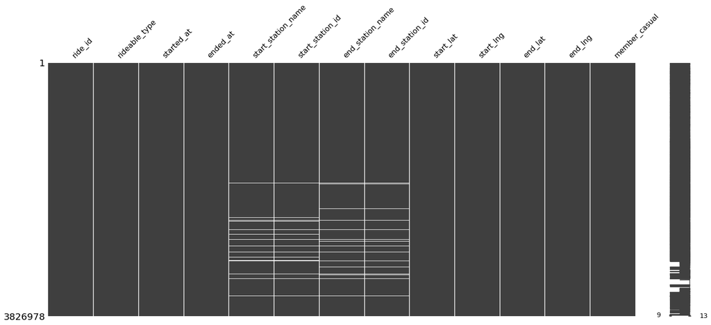

```python
#Visualize missing values
msno.matrix(tripDf)
plt.show()
```

# Let's get ride_duration so as to aid the cleaning process

Ensuring that columns with datetime information are properly in datetime format

```python
#Convert to datetime
tripDf['started_at'] = pd.to_datetime(tripDf['started_at'], format="%Y%m%d %H:%M:%S")
tripDf['ended_at'] = pd.to_datetime(tripDf['ended_at'], format="%Y%m%d %H:%M:%S")
```

```python
tripDf['ride_duration'] = tripDf['ended_at'] - tripDf['started_at']
```

```python
tripDf.info()
```

```
<class 'pandas.core.frame.DataFrame'>
RangeIndex: 3826978 entries, 0 to 3826977
Data columns (total 14 columns):
 #   Column              Dtype
---  ------              -----
 0   ride_id             object
 1   rideable_type       object
 2   started_at          datetime64[ns]
 3   ended_at            datetime64[ns]
 4   start_station_name  object
 5   start_station_id    object
 6   end_station_name    object
 7   end_station_id      object
 8   start_lat           float64
 9   start_lng           float64
 10  end_lat             float64
 11  end_lng             float64
 12  member_casual       object
 13  ride_duration       timedelta64[ns]
dtypes: datetime64[ns](2), float64(4), object(7), timedelta64[ns](1)
memory usage: 408.8+ MB
```

## Let's take a look at the missing values on end_stations and see why there are missing values

```python
missing_end = tripDf[tripDf['end_station_name'].isna()]
missing_end.head(15)
```

|  | ride_id | rideable_type | started_at | ended_at | start_station_name | start_station_id | end_station_name | end_station_id | start_lat | start_lng | end_lat | end_lng | member_casual | ride_duration |
| --- | --- | --- | --- | --- | --- | --- | --- | --- | --- | --- | --- | --- | --- | --- |
| 1001 | 5E2BD03BCA180FBA | docked_bike | 2020-04-07 11:53:08 | 2020-04-07 12:28:35 | Wells St & Concord Ln | 289 | NaN | NaN | 41.9121 | -87.6347 | NaN | NaN | member | 0 days 00:35:27 |
| 1864 | BD5813A6101E9BF4 | docked_bike | 2020-04-20 12:24:48 | 2020-04-20 12:29:46 | Racine Ave & Wrightwood Ave | 343 | NaN | NaN | 41.9289 | -87.6590 | NaN | NaN | member | 0 days 00:04:58 |
| 2167 | 228691849C2081EE | docked_bike | 2020-04-16 08:41:56 | 2020-04-16 11:33:48 | Racine Ave & 18th St | 15 | NaN | NaN | 41.8582 | -87.6565 | NaN | NaN | member | 0 days 02:51:52 |
| 2458 | ED7750BCEEE87174 | docked_bike | 2020-04-09 15:33:45 | 2020-04-09 16:34:54 | Morgan Ave & 14th Pl | 137 | NaN | NaN | 41.8624 | -87.6511 | NaN | NaN | casual | 0 days 01:01:09 |
| 3834 | 1E00C457DCDA0835 | docked_bike | 2020-04-25 06:52:02 | 2020-04-25 07:17:54 | Lake Shore Dr & Wellington Ave | 157 | NaN | NaN | 41.9367 | -87.6368 | NaN | NaN | member | 0 days 00:25:52 |
| 5100 | 0F7201752882C449 | docked_bike | 2020-04-30 20:47:40 | 2020-04-30 21:19:00 | Ashland Ave & Chicago Ave | 350 | NaN | NaN | 41.8960 | -87.6677 | NaN | NaN | member | 0 days 00:31:20 |
| 5794 | 97C00C77F12AF5AE | docked_bike | 2020-04-10 11:54:44 | 2020-04-10 12:02:39 | Wells St & Huron St | 53 | NaN | NaN | 41.8947 | -87.6344 | NaN | NaN | member | 0 days 00:07:55 |
| 7251 | E0AFDC4D2358B027 | docked_bike | 2020-04-20 13:37:30 | 2020-04-20 14:27:48 | State St & Pearson St | 106 | NaN | NaN | 41.8974 | -87.6287 | NaN | NaN | casual | 0 days 00:50:18 |
| 7404 | 8BAB90CEE039C959 | docked_bike | 2020-04-28 16:21:26 | 2020-04-28 17:03:01 | Bissell St & Armitage Ave | 113 | NaN | NaN | 41.9184 | -87.6522 | NaN | NaN | casual | 0 days 00:41:35 |
| 9034 | 8BC76B362DA665B7 | docked_bike | 2020-04-19 13:23:39 | 2020-04-19 13:58:52 | Central Park Ave & North Ave | 508 | NaN | NaN | 41.9097 | -87.7166 | NaN | NaN | member | 0 days 00:35:13 |
| 9551 | CA182D7FDACC427D | docked_bike | 2020-04-08 12:44:18 | 2020-04-09 13:44:09 | Phillips Ave & 79th St | 579 | NaN | NaN | 41.7518 | -87.5652 | NaN | NaN | casual | 1 days 00:59:51 |
| 9578 | 74D33D6F25179262 | docked_bike | 2020-04-18 13:01:33 | 2020-04-18 14:20:45 | Wells St & Evergreen Ave | 291 | NaN | NaN | 41.9067 | -87.6348 | NaN | NaN | casual | 0 days 01:19:12 |
| 9779 | 72F15ADC62F9A5E6 | docked_bike | 2020-04-12 14:24:21 | 2020-04-12 14:51:00 | Lincoln Ave & Waveland Ave | 257 | NaN | NaN | 41.9488 | -87.6753 | NaN | NaN | member | 0 days 00:26:39 |
| 10125 | 2DE1FC1F7CC6AD71 | docked_bike | 2020-04-26 11:09:20 | 2020-04-26 11:20:18 | Ashland Ave & Wrightwood Ave | 166 | NaN | NaN | 41.9288 | -87.6685 | NaN | NaN | member | 0 days 00:10:58 |
| 10614 | A5A3A8807AFE36AC | docked_bike | 2020-04-18 15:21:28 | 2020-04-18 15:49:09 | Lincoln Ave & Belmont Ave | 131 | NaN | NaN | 41.9394 | -87.6684 | NaN | NaN | member | 0 days 00:27:41 |

### Looking at the first 15 rows of missing values inside the columns regarding end_stations, it seems that it is missing either due to the customer canceled their ride or other reasons

## Let's now take a look at why start_stations are missing

```python
missing_start = tripDf[tripDf['start_station_name'].isna()]
missing_start.head(15)
```

|  | ride_id | rideable_type | started_at | ended_at | start_station_name | start_station_id | end_station_name | end_station_id | start_lat | start_lng | end_lat | end_lng | member_casual | ride_duration |
| --- | --- | --- | --- | --- | --- | --- | --- | --- | --- | --- | --- | --- | --- | --- |
| 630367 | 60742256DFFFCA29 | electric_bike | 2020-07-31 08:30:34 | 2020-07-31 08:57:54 | NaN | NaN | Racine Ave & 35th St | 367.0 | 41.90 | -87.69 | 41.830704 | -87.656085 | member | 0 days 00:27:20 |
| 642029 | EBBD4FE9C8A95116 | electric_bike | 2020-07-29 19:02:25 | 2020-07-29 19:22:40 | NaN | NaN | Western Ave & Walton St | 374.0 | 41.90 | -87.69 | 41.898404 | -87.686592 | member | 0 days 00:20:15 |
| 653657 | 976336C6499A7189 | electric_bike | 2020-07-30 22:02:45 | 2020-07-30 22:17:54 | NaN | NaN | Clarendon Ave & Leland Ave | 251.0 | 41.94 | -87.65 | 41.967841 | -87.649991 | member | 0 days 00:15:09 |
| 670853 | EC549CDABDE45F98 | electric_bike | 2020-07-31 15:54:41 | 2020-07-31 16:00:35 | NaN | NaN | NaN | NaN | 41.92 | -87.70 | 41.910000 | -87.680000 | member | 0 days 00:05:54 |
| 670856 | 70F53BFE303499AC | electric_bike | 2020-07-31 16:08:26 | 2020-07-31 16:15:29 | NaN | NaN | NaN | NaN | 41.91 | -87.68 | 41.920000 | -87.700000 | member | 0 days 00:07:03 |
| 670859 | 11814668BAB6FCA3 | electric_bike | 2020-07-31 12:56:53 | 2020-07-31 13:13:27 | NaN | NaN | Aberdeen St & Randolph St | 621.0 | 41.86 | -87.63 | 41.884041 | -87.654301 | member | 0 days 00:16:34 |
| 686820 | D66AC7ACF66F8FF6 | electric_bike | 2020-07-30 08:32:14 | 2020-07-30 08:40:04 | NaN | NaN | Canal St & Madison St | 174.0 | 41.87 | -87.65 | 41.881760 | -87.640163 | member | 0 days 00:07:50 |
| 709525 | 5196A992F09481DB | electric_bike | 2020-07-30 17:25:18 | 2020-07-30 17:25:35 | NaN | NaN | NaN | NaN | 41.90 | -87.62 | 41.900000 | -87.620000 | member | 0 days 00:00:17 |
| 709526 | 2DB97E499E497D3D | electric_bike | 2020-07-30 17:28:20 | 2020-07-30 17:44:40 | NaN | NaN | Financial Pl & Ida B Wells Dr | 89.0 | 41.90 | -87.62 | 41.874970 | -87.633277 | member | 0 days 00:16:20 |
| 709527 | 3C5018A592AB147C | electric_bike | 2020-07-31 18:40:31 | 2020-07-31 18:48:56 | NaN | NaN | Keystone Ave & Montrose Ave | 495.0 | 41.97 | -87.73 | 41.961081 | -87.729016 | member | 0 days 00:08:25 |
| 709528 | 836BE807C2FFC1DB | electric_bike | 2020-07-31 18:39:02 | 2020-07-31 18:39:13 | NaN | NaN | NaN | NaN | 41.97 | -87.73 | 41.970000 | -87.730000 | member | 0 days 00:00:11 |
| 718527 | D53BD878D7CF3DDA | electric_bike | 2020-07-30 17:17:45 | 2020-07-30 17:35:15 | NaN | NaN | NaN | NaN | 41.86 | -87.61 | 41.880000 | -87.620000 | member | 0 days 00:17:30 |
| 756172 | 821A0CD56410BE85 | electric_bike | 2020-07-31 01:10:40 | 2020-07-31 01:21:08 | NaN | NaN | Leavitt St & Belmont Ave | 664.0 | 41.91 | -87.68 | 41.939366 | -87.683256 | casual | 0 days 00:10:28 |
| 756190 | 60A3D6C3238E5D1B | electric_bike | 2020-07-29 15:38:31 | 2020-07-29 15:55:27 | NaN | NaN | Prairie Ave & 43rd St | 410.0 | 41.80 | -87.59 | 41.816691 | -87.619329 | casual | 0 days 00:16:56 |
| 756201 | FA92AAEFE87BD7EA | electric_bike | 2020-07-15 10:20:31 | 2020-07-15 10:20:57 | NaN | NaN | NaN | NaN | 41.89 | -87.68 | 41.890000 | -87.680000 | casual | 0 days 00:00:26 |

## Seems mixed as to why they are missing. Some, with just seconds of ride_duration can be safely assumed that the rider must've changed his mind. Now I will drop rows that have both start and end station empty.

```python
# if tripDf[tripDf[['start_station_name', 'start_station_id', 'end_station_name', 'end_station_id']].isna()]:
#     tripDf.dropna()

cols = ['start_station_name', 'start_station_id', 'end_station_name', 'end_station_id']
# cols = ['start_station_name', 'end_station_name']

na_list = tripDf[
        (tripDf['start_station_name'].isna()) &
        (tripDf['start_station_id'].isna()) &
        (tripDf['end_station_name'].isna()) &
        (tripDf['end_station_id'].isna())
    ]

na_list.shape
```

```
(86439, 14)
```

### There are more 86,439 rows with all four of the start and end station id/name missing in values. As a result, I cannot safely determine whether the riders had merely changed their minds or there was a techincal error back then.

### After much deliberation and checking on the internet, I've realized that these missing values won't affect my analysis and conclusions, as further on I've also realized I should only be concerned on values that are in the negatives on the ride duration.

## Now I will determine what day it was borrowed on that week and whether it is a weekend or weekday

```python
tripDf['day_borrowed'] = tripDf['started_at'].dt.day_name()

tripDf.head()
```

|  | ride_id | rideable_type | started_at | ended_at | start_station_name | start_station_id | end_station_name | end_station_id | start_lat | start_lng | end_lat | end_lng | member_casual | ride_duration | day_borrowed |
| --- | --- | --- | --- | --- | --- | --- | --- | --- | --- | --- | --- | --- | --- | --- | --- |
| 0 | A847FADBBC638E45 | docked_bike | 2020-04-26 17:45:14 | 2020-04-26 18:12:03 | Eckhart Park | 86 | Lincoln Ave & Diversey Pkwy | 152.0 | 41.8964 | -87.6610 | 41.9322 | -87.6586 | member | 0 days 00:26:49 | Sunday |
| 1 | 5405B80E996FF60D | docked_bike | 2020-04-17 17:08:54 | 2020-04-17 17:17:03 | Drake Ave & Fullerton Ave | 503 | Kosciuszko Park | 499.0 | 41.9244 | -87.7154 | 41.9306 | -87.7238 | member | 0 days 00:08:09 | Friday |
| 2 | 5DD24A79A4E006F4 | docked_bike | 2020-04-01 17:54:13 | 2020-04-01 18:08:36 | McClurg Ct & Erie St | 142 | Indiana Ave & Roosevelt Rd | 255.0 | 41.8945 | -87.6179 | 41.8679 | -87.6230 | member | 0 days 00:14:23 | Wednesday |
| 3 | 2A59BBDF5CDBA725 | docked_bike | 2020-04-07 12:50:19 | 2020-04-07 13:02:31 | California Ave & Division St | 216 | Wood St & Augusta Blvd | 657.0 | 41.9030 | -87.6975 | 41.8992 | -87.6722 | member | 0 days 00:12:12 | Tuesday |
| 4 | 27AD306C119C6158 | docked_bike | 2020-04-18 10:22:59 | 2020-04-18 11:15:54 | Rush St & Hubbard St | 125 | Sheridan Rd & Lawrence Ave | 323.0 | 41.8902 | -87.6262 | 41.9695 | -87.6547 | casual | 0 days 00:52:55 | Saturday |

```python
#Convert to Weekday or Weekend

tripDf['weekend_weekday'] = np.where(tripDf['started_at'].dt.dayofweek > 4, 'Weekend', 'Weekday')


tripDf.head()
```

|  | ride_id | rideable_type | started_at | ended_at | start_station_name | start_station_id | end_station_name | end_station_id | start_lat | start_lng | end_lat | end_lng | member_casual | ride_duration | day_borrowed | weekend_weekday |
| --- | --- | --- | --- | --- | --- | --- | --- | --- | --- | --- | --- | --- | --- | --- | --- | --- |
| 0 | A847FADBBC638E45 | docked_bike | 2020-04-26 17:45:14 | 2020-04-26 18:12:03 | Eckhart Park | 86 | Lincoln Ave & Diversey Pkwy | 152.0 | 41.8964 | -87.6610 | 41.9322 | -87.6586 | member | 0 days 00:26:49 | Sunday | Weekend |
| 1 | 5405B80E996FF60D | docked_bike | 2020-04-17 17:08:54 | 2020-04-17 17:17:03 | Drake Ave & Fullerton Ave | 503 | Kosciuszko Park | 499.0 | 41.9244 | -87.7154 | 41.9306 | -87.7238 | member | 0 days 00:08:09 | Friday | Weekday |
| 2 | 5DD24A79A4E006F4 | docked_bike | 2020-04-01 17:54:13 | 2020-04-01 18:08:36 | McClurg Ct & Erie St | 142 | Indiana Ave & Roosevelt Rd | 255.0 | 41.8945 | -87.6179 | 41.8679 | -87.6230 | member | 0 days 00:14:23 | Wednesday | Weekday |
| 3 | 2A59BBDF5CDBA725 | docked_bike | 2020-04-07 12:50:19 | 2020-04-07 13:02:31 | California Ave & Division St | 216 | Wood St & Augusta Blvd | 657.0 | 41.9030 | -87.6975 | 41.8992 | -87.6722 | member | 0 days 00:12:12 | Tuesday | Weekday |
| 4 | 27AD306C119C6158 | docked_bike | 2020-04-18 10:22:59 | 2020-04-18 11:15:54 | Rush St & Hubbard St | 125 | Sheridan Rd & Lawrence Ave | 323.0 | 41.8902 | -87.6262 | 41.9695 | -87.6547 | casual | 0 days 00:52:55 | Saturday | Weekend |

## Adding the weekend_weekday and day_borrowed fields will further assist me to visualize certain trends later on the Analysis phase.

#### One last thing before proceeding to the analyze phase, I will now remove the underscore in the rideable_type column and capitalize the first letters to make it look better for visualization later on.

```python
tripDf['rideable_type'].unique() # 'docked_bike', 'electric_bike', 'classic_bike

tripDf['rideable_type'] = tripDf.loc[:,'rideable_type'].str.title().str.replace('_', ' ')

tripDf.head(10)
```

|  | ride_id | rideable_type | started_at | ended_at | start_station_name | start_station_id | end_station_name | end_station_id | start_lat | start_lng | end_lat | end_lng | member_casual | ride_duration | day_borrowed | weekend_weekday |
| --- | --- | --- | --- | --- | --- | --- | --- | --- | --- | --- | --- | --- | --- | --- | --- | --- |
| 0 | A847FADBBC638E45 | Docked Bike | 2020-04-26 17:45:14 | 2020-04-26 18:12:03 | Eckhart Park | 86 | Lincoln Ave & Diversey Pkwy | 152.0 | 41.8964 | -87.6610 | 41.9322 | -87.6586 | member | 0 days 00:26:49 | Sunday | Weekend |
| 1 | 5405B80E996FF60D | Docked Bike | 2020-04-17 17:08:54 | 2020-04-17 17:17:03 | Drake Ave & Fullerton Ave | 503 | Kosciuszko Park | 499.0 | 41.9244 | -87.7154 | 41.9306 | -87.7238 | member | 0 days 00:08:09 | Friday | Weekday |
| 2 | 5DD24A79A4E006F4 | Docked Bike | 2020-04-01 17:54:13 | 2020-04-01 18:08:36 | McClurg Ct & Erie St | 142 | Indiana Ave & Roosevelt Rd | 255.0 | 41.8945 | -87.6179 | 41.8679 | -87.6230 | member | 0 days 00:14:23 | Wednesday | Weekday |
| 3 | 2A59BBDF5CDBA725 | Docked Bike | 2020-04-07 12:50:19 | 2020-04-07 13:02:31 | California Ave & Division St | 216 | Wood St & Augusta Blvd | 657.0 | 41.9030 | -87.6975 | 41.8992 | -87.6722 | member | 0 days 00:12:12 | Tuesday | Weekday |
| 4 | 27AD306C119C6158 | Docked Bike | 2020-04-18 10:22:59 | 2020-04-18 11:15:54 | Rush St & Hubbard St | 125 | Sheridan Rd & Lawrence Ave | 323.0 | 41.8902 | -87.6262 | 41.9695 | -87.6547 | casual | 0 days 00:52:55 | Saturday | Weekend |
| 5 | 356216E875132F61 | Docked Bike | 2020-04-30 17:55:47 | 2020-04-30 18:01:11 | Mies van der Rohe Way & Chicago Ave | 173 | Streeter Dr & Grand Ave | 35.0 | 41.8969 | -87.6217 | 41.8923 | -87.6120 | member | 0 days 00:05:24 | Thursday | Weekday |
| 6 | A2759CB06A81F2BC | Docked Bike | 2020-04-02 14:47:19 | 2020-04-02 14:52:32 | Streeter Dr & Grand Ave | 35 | Fairbanks St & Superior St | 635.0 | 41.8923 | -87.6120 | 41.8957 | -87.6201 | member | 0 days 00:05:13 | Thursday | Weekday |
| 7 | FC8BC2E2D54F35ED | Docked Bike | 2020-04-07 12:22:20 | 2020-04-07 13:38:09 | Ogden Ave & Roosevelt Rd | 434 | Western Ave & Congress Pkwy | 382.0 | 41.8665 | -87.6847 | 41.8747 | -87.6864 | casual | 0 days 01:15:49 | Tuesday | Weekday |
| 8 | 9EC5648678DE06E6 | Docked Bike | 2020-04-15 10:30:11 | 2020-04-15 10:35:55 | LaSalle Dr & Huron St | 627 | Larrabee St & Division St | 359.0 | 41.8949 | -87.6323 | 41.9035 | -87.6434 | casual | 0 days 00:05:44 | Wednesday | Weekday |
| 9 | A8FFF89140C33017 | Docked Bike | 2020-04-04 15:02:28 | 2020-04-04 15:19:47 | Kedzie Ave & Lake St | 377 | Central Park Ave & North Ave | 508.0 | 41.8846 | -87.7063 | 41.9097 | -87.7166 | member | 0 days 00:17:19 | Saturday | Weekend |

# Analyze Phase

## As a refresher, these are the questions I am interested in:

- What is the total number of trips for members and casuals, and what proportion of total trips do they represent?
- What are the average ride lengths for members and casuals respectively?
- What are the most common starting and ending stations for each?
- Are there particular days of the week on which most rides take place?
- Is there a preference for the rideable type for members and casuals?

# First Question: What is the total number of trips for members and casuals, and what proportion of total trips do they represent?

Let's look at the unique counts of members and casuals.

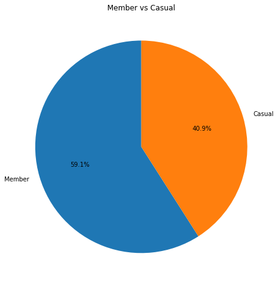

```
member    59.054455
casual    40.945545
Name: member_casual, dtype: float64
```

```python
member_casual_count = tripDf['member_casual'].value_counts()

# member_casual_count.plot(kind = 'pie', title = "Member vs Casual")

fig, ax = plt.subplots()

ax.pie(
        member_casual_count,
        autopct='%1.1f%%',
        labels = ['Member', 'Casual'],
        startangle=90,
    )

plt.title("Member vs Casual")
fig.set_size_inches([8, 8])

plt.show()
#There are 226001 members and 1566977 casuals

member_casual_proportion = tripDf['member_casual'].value_counts(normalize=True)
print(member_casual_proportion * 100)
```

# Second Question: What are the average ride lengths for members and casuals respectively?

Let's take a look at the summary statistics:

```python
tripDf['ride_duration'].describe()
```

```
count                      3826978
mean     0 days 00:24:42.689237304
std      0 days 06:17:58.646501483
min             -21 days +19:50:02
25%                0 days 00:07:48
50%                0 days 00:14:21
75%                0 days 00:26:23
max               40 days 18:40:02
Name: ride_duration, dtype: object
```

The minimum is actually on the negative side. Let's check how many of them are actually negative values.

```python
less_0_sec = tripDf.loc[tripDf['ride_duration'] <= datetime.timedelta(seconds = 0), 'ride_duration'].shape # 10976 rows
```

```python
excluded = tripDf[tripDf['ride_duration'] >= datetime.timedelta(seconds = 0)] #this ensures no negative values are included

# tripDf.shape #3,826,978

excluded.shape #3,816,421. about 10,000 rows are excluded.

excluded['ride_duration'].describe()
```

```
count                      3816421
mean     0 days 00:27:36.851399780
std      0 days 04:09:19.799293299
min                0 days 00:00:00
25%                0 days 00:07:51
50%                0 days 00:14:24
75%                0 days 00:26:26
max               40 days 18:40:02
Name: ride_duration, dtype: object
```

### Now that I've excluded the ones that have negative values on the ride_duration, the statistical summary makes more sense now. The average that the customers typically rides per session is 27 minuters, which is quite reasonable.

# What is the average ride duration of casual riders and member riders?

```python
member_only = excluded[excluded['member_casual'] == 'member']
casual_only = excluded[excluded['member_casual'] == 'casual']

#Double check if I filtered it right
print(member_only['member_casual'].unique())
print(casual_only['member_casual'].unique())

print('\n')
print('This statistical summary excludes casual riders')
print(member_only['ride_duration'].describe())
print('\n')
print('This statistical summary excludes member riders')
print(casual_only['ride_duration'].describe())
```

```
['member']
['casual']


This statistical summary excludes casual riders
count                      2252699
mean     0 days 00:15:59.287310466
std      0 days 01:28:36.864600156
min                0 days 00:00:00
25%                0 days 00:06:28
50%                0 days 00:11:23
75%                0 days 00:19:55
max               40 days 18:40:02
Name: ride_duration, dtype: object


This statistical summary excludes member riders
count                      1563722
mean     0 days 00:44:21.762711658
std      0 days 06:14:04.612557996
min                0 days 00:00:00
25%                0 days 00:11:24
50%                0 days 00:20:56
75%                0 days 00:39:43
max               38 days 16:03:53
Name: ride_duration, dtype: object
```

### Surprisingly, casual riders' average as compared to member riders is longer! Therefore, I can deduce that members don't actually ride longer than casual riders, but the other way around instead!

# Finally, let's now calculate the average ride time (minutes) on each month for each rider type

```python
#adding a new column containing the month name
tripDf['month_borrowed'] = pd.to_datetime(tripDf['started_at']).dt.strftime('%B %Y')
# tripDf['month_borrowed'] = pd.to_datetime(tripDf['month_borrowed'], format = '%B %Y')

#make sure to exclude negative values
excluded = tripDf[tripDf['ride_duration'] >= datetime.timedelta(seconds = 0)]
excluded['ride_duration'].describe()
```

```
count                      3816421
mean     0 days 00:27:36.851399780
std      0 days 04:09:19.799293299
min                0 days 00:00:00
25%                0 days 00:07:51
50%                0 days 00:14:24
75%                0 days 00:26:26
max               40 days 18:40:02
Name: ride_duration, dtype: object
```

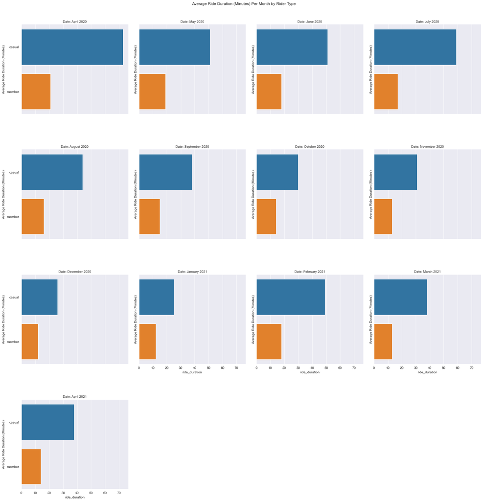

```python
summary_ride_duration = excluded.groupby('month_borrowed')['ride_duration'].describe()
# print(summary_ride_duration)

grouped = excluded.groupby(['month_borrowed', 'member_casual'], as_index = False)['ride_duration']
ride_avg = grouped.apply(lambda x: np.mean(x))

df = pd.DataFrame(ride_avg)

#convert to minutes
df['ride_duration'] = df['ride_duration'].astype('timedelta64[m]')

#sort by month
df['month_borrowed'] = pd.to_datetime(df['month_borrowed'])
df = df.sort_values(by = 'month_borrowed')

#convert back to (Month_Name Year) format
df['month_borrowed'] = pd.to_datetime(df['month_borrowed']).dt.strftime('%B %Y')

sns.set_style("darkgrid")

plt.figure(figsize=[15,7])
ride_dur = sns.catplot(
    x = 'ride_duration',
    y = 'member_casual',
    data = df,
    col = 'month_borrowed',
    col_wrap = 4,
    kind = 'bar')

ride_dur.set(
    ylabel = "Average Ride Duration (Minutes)"
)

ride_dur.fig.suptitle('Average Ride Duration (Minutes) Per Month by Rider Type',  y = 1.03)
ride_dur.set_titles("Date: {col_name}")
plt.subplots_adjust(hspace=0.4, wspace=0.1)
```

### It seems that riders ride the longest in terms of average from February until September. And from October until January there's a lower average ride duration for both member and casual riders.

### Let's now look at whether the day of the week has any correlation with how frequent casual/member riders would rent bikes.

```
[Text(0.5, 0, 'Day of the Week Borrowed'),
```

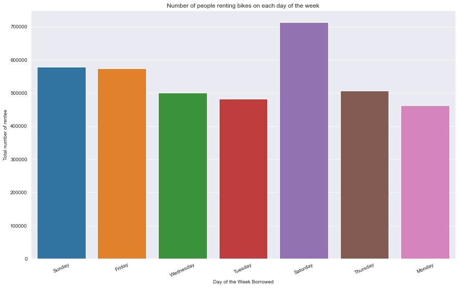

```python
fig_dims = (15, 9)
fig, ax = plt.subplots(figsize=fig_dims)

day_borrowed = sns.countplot(
    data = excluded,
    x = 'day_borrowed',
    ax = ax
)

day_borrowed.set_title('Number of people renting bikes on each day of the week')
plt.xticks(rotation = 25)
day_borrowed.set(xlabel = 'Day of the Week Borrowed', ylabel = 'Total number of rentee')
```

### As we can see above, most riders prefer to cycle on a Saturday. As a result, this is an interesting insight that may be useful later on.

### Let's now take a look if there's a difference between when member/casual riders tend to ride.

```
[Text(0.5, 0, 'Day of the Week Borrowed'),
```

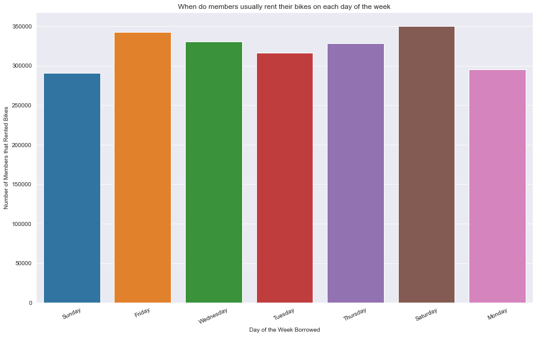

```python
fig_dims = (15, 9)
fig, ax = plt.subplots(figsize=fig_dims)

day_borrowed = sns.countplot(
    data = member_only,
    x = 'day_borrowed',
    ax = ax
)

day_borrowed.set_title('When do members usually rent their bikes on each day of the week')
plt.xticks(rotation = 25)

day_borrowed.set(xlabel = 'Day of the Week Borrowed', ylabel = 'Number of Members that Rented Bikes')
```

```
[Text(0.5, 0, 'Day of the Week Borrowed'),
```

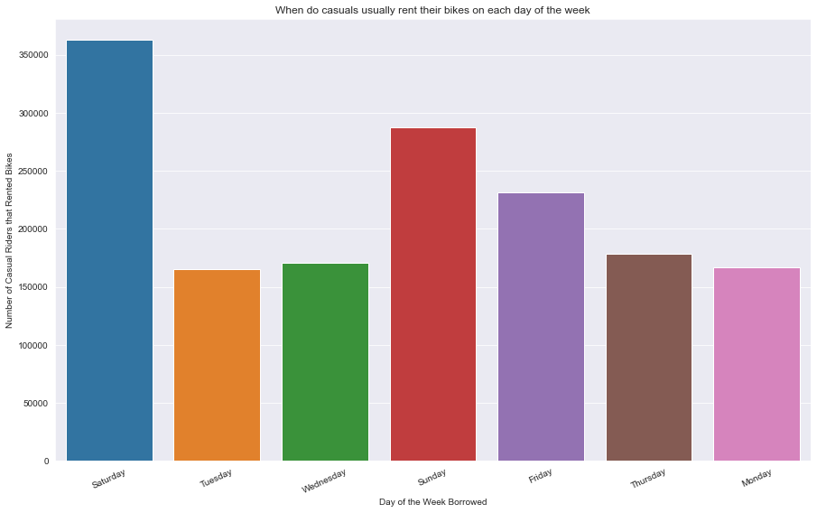

```python
fig_dims = (15, 9)
fig, ax = plt.subplots(figsize=fig_dims)

day_borrowed = sns.countplot(
    data = casual_only,
    x = 'day_borrowed',
    ax = ax
)

day_borrowed.set_title('When do casuals usually rent their bikes on each day of the week')
plt.xticks(rotation = 25)

day_borrowed.set(xlabel = 'Day of the Week Borrowed', ylabel = 'Number of Casual Riders that Rented Bikes')
```

Interesting! If the company ever wants to perform an advertisement to convince casual riders to convert into annual membership, I can suggest that they should emphasize doing it more on Saturdays! Also, it seems that both members and casual riders prefer to ride on Saturdays, therefore doing an advertisement on a Saturday not only enables the company to potentially convince casual riders to subscribe to an annual subsription, but also retain the member riders to renew their membership!

This coincidentally is the fourth question that I wanted to answer to, which is: Are there particular days of the week on which most rides take place? Therefore I will now move on to the next question and after that I will start tackling the fifth and last question of my business objectives.

# Next Question: What are the most common starting and ending stations for each?

To identify this, let's take a look at their respective stations' countplot.

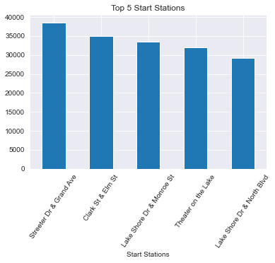

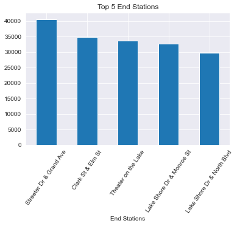

```python
#Top 5 start stations
top_5_start = excluded["start_station_name"].value_counts().head(5).plot(kind = 'bar', rot = 55, title = 'Top 5 Start Stations', xlabel = 'Start Stations')
plt.show()
top_5_end = excluded["end_station_name"].value_counts().head(5).plot(kind = 'bar', rot = 55, title = 'Top 5 End Stations', xlabel = 'End Stations')
plt.show()
```

## These top 5 locations are the most rented in both the start and end stations if we account both members and casual riders.

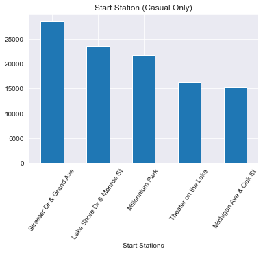

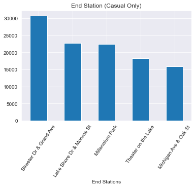

```python
top_5_start = casual_only["start_station_name"].value_counts().head(5).plot(kind = 'bar', rot = 55, title = "Start Station (Casual Only)", xlabel = 'Start Stations')
plt.show()
top_5_end = casual_only["end_station_name"].value_counts().head(5).plot(kind = 'bar', rot = 55, title = "End Station (Casual Only)", xlabel = 'End Stations')
plt.show()
```

### These are the top 5 locations that casual riders mostly rent their bikes. If the company wishes to target on casual riders for their advertisement, these 5 locations are highly recommended for the company to concentrate their advertisement on.

# Last Question: Is there a preference for the rideable type for members and casuals?

### Let's examine the rideable_type column!

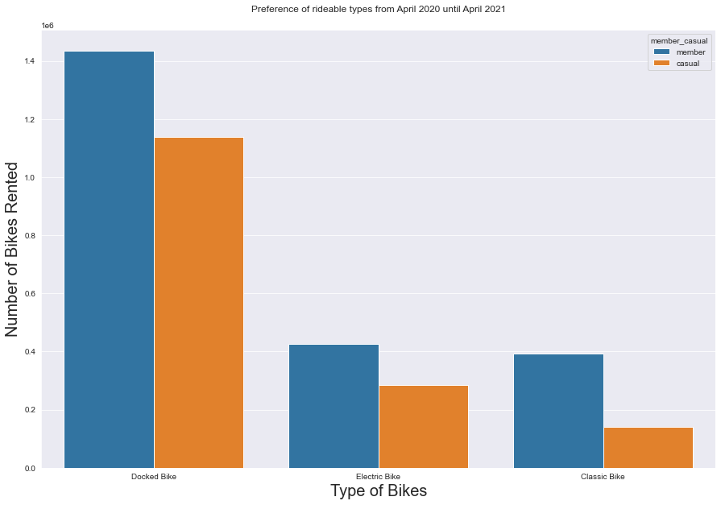

```python
ride_type = excluded['rideable_type'].value_counts(normalize = True)

fig_dims = (15, 10)
fig, ax = plt.subplots(figsize=fig_dims)
plt.rcParams["axes.labelsize"] = 20

ride_p = sns.countplot(
    data = excluded,
    x = 'rideable_type',
    hue = 'member_casual',
    ax = ax
)

ride_p.set_title('Preference of rideable types from April 2020 until April 2021',  y = 1.03)
ride_p.set(xlabel = 'Type of Bikes', ylabel = 'Number of Bikes Rented')

plt.show()
```

### As can be seen above, no matter if it's member or casual, the docked bike is the most popular, followed by electric bikes and classic bikes.

### This data doens't seem accurate if we look at it overall. Let's look at it by by month instead.

```python
summary = excluded.groupby('month_borrowed')['rideable_type'].describe()
# equivalent to summary = excluded.groupby('month_borrowed')['rideable_type'].aggregate(['count', pd.Series.mode])

sorted_summary = summary.sort_values(by = "count", ascending = False)

print(sorted_summary)
```

```
                 count unique           top    freq
month_borrowed
August 2020     619592      2   Docked Bike  553403
July 2020       549735      2   Docked Bike  547801
September 2020  530826      2   Docked Bike  402479
October 2020    386742      2   Docked Bike  234574
June 2020       342536      1   Docked Bike  342536
April 2021      337225      3  Classic Bike  214616
November 2020   258851      2   Docked Bike  150734
March 2021      228494      3  Classic Bike  152544
May 2020        200102      1   Docked Bike  200102
December 2020   131139      3  Classic Bike   70616
January 2021     96832      3  Classic Bike   61699
April 2020       84725      1   Docked Bike   84725
February 2021    49622      3  Classic Bike   35012
```

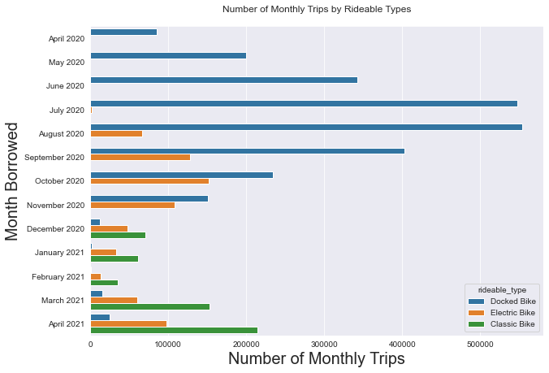

```python
fig_dims = (10, 7)
fig, ax = plt.subplots(figsize = fig_dims)

ride_p = sns.countplot(
    data = excluded,
    y = 'month_borrowed',
    hue = 'rideable_type',
    ax = ax
)

# ax.set_xticklabels(ax.get_xticklabels(),rotation = 30)

ride_p.set(xlabel = 'Number of Monthly Trips', ylabel = 'Month Borrowed')
ride_p.set_title('Number of Monthly Trips by Rideable Types',  y = 1.03)
```

It seems that August 2020 was the most busiest in terms of how many people rented the bicycles. Docked bikes were the most used from April 2020 to November 2020. However after November 2020, it seems to have lost its popularity. With the summary statistics, I can confirm that from April-June 2020, there seems to be only data pertaining docked bikes. It also seems that electric bikes are slowly becoming popular starting from August 2020. And for some reason, classic bikes seems to be growing in popularity starting from December 2020.

To get a better picture, let's visualize popular rideable type bikes per month and separate them by whether they are members or casuals.

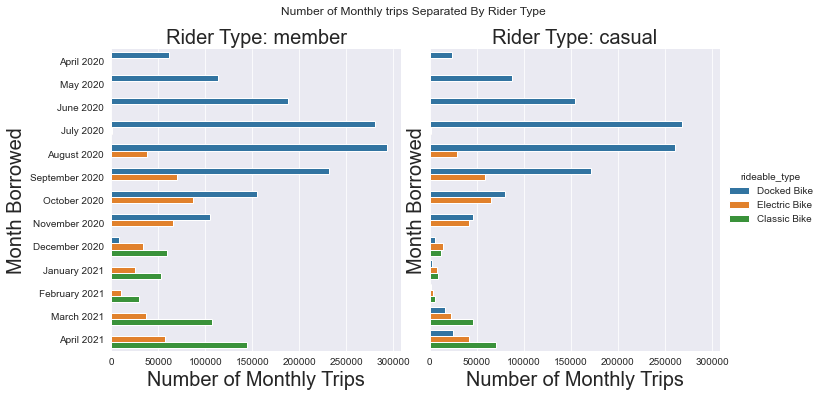

```python
ride_grouped = sns.catplot(
    data = excluded,
    y = 'month_borrowed',
    kind = 'count',
    hue = 'rideable_type',
    col = 'member_casual'
)

ride_grouped.set(
    ylabel = "Month Borrowed",
    xlabel = 'Number of Monthly Trips'
)

ride_grouped.fig.suptitle('Number of Monthly trips Separated By Rider Type',  y = 1.03)
ride_grouped.set_titles("Rider Type: {col_name}")
plt.subplots_adjust(hspace=0.4, wspace=0.1)
```

# Let's take a look at how many rider types overall rode in each month.

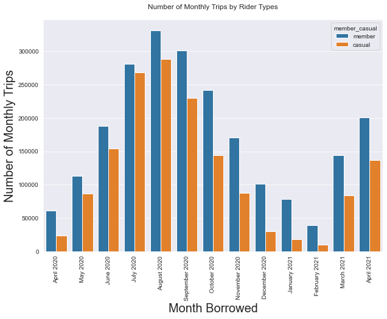

```python
summary_rider_type = excluded.groupby('month_borrowed')['member_casual'].describe()
# print(summary_rider_type) <- This is to double check

fig_dims = (10, 7)
fig, ax = plt.subplots(figsize = fig_dims)

ride_p = sns.countplot(
    data = excluded,
    x = 'month_borrowed',
    hue = 'member_casual',
    ax = ax
)

ride_p.set(xlabel = 'Month Borrowed', ylabel = 'Number of Monthly Trips')
ride_p.set_title('Number of Monthly Trips by Rider Types',  y = 1.03)
plt.xticks(rotation = 90)
plt.show();
```

### With this chart, it seems that beginning in April the number of trips starts to rise and peaks at August. After August, the number of trips starts to fall.

# Act Phase (Conclusion)

From the data that I have examined, I will give these recommendations: